# A simple model for dynamics of beliefs

gpc

05/10/2014

## Society as a graph

Consider for illustration a small society with $5$ individuals names `JP`, `AA`, `J`, `B` and `JBM`. It is represented by a graph such as the one below. The vertices are the individuals and the edges are the connections between individuals.

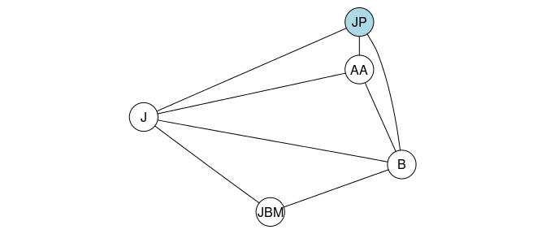

This graph is easy to plot in R using the `graph` and `Rgraphviz` packages. One starts with a matrix of connections `M`:

```r
M
```

```
##    AA  J  B JBM
## JP  1  1  1   0
## AA NA  1  1   0
## J  NA NA  1   1
## B  NA NA NA   1
```

prettier rendered like this (for those who are not familiar with R outputs):

$\begin{array}{r|c|c|c|c} & AA & J & B & JBM \\ \hline JP & 1 & 1 & 1 & 0 \\ \hline AA & & 1 & 1 & 0 \\ \hline J & & & 1 & 1 \\ \hline B & & & & 1 \\ \end{array}$

A `0` means no connection between the two individuals, a `1` means connection between the two individuals (connected individuals meet sometimes). Then the graph is constructed and plotted by the following code:

```r
library(Rgraphviz)
g <- new("graphNEL", nodes=members, edgemode="undirected")
for(i in 1:nrow(M)){
  connections <- which(M[i,]>0)
  if(length(connections)){
    for(j in connections){
      g <- addEdge(rownames(M)[i], colnames(M)[j], g, M[i,j])
    }
  }
}
#plot(g)
g <- layoutGraph(g)
nodeRenderInfo(g) <- list(fill=c("JP"="lightblue"))
renderGraph(g)
```

Individual `JP` will play a special role later, that’s why we use a color for his vertex.

For fun, we can generate a Javascript graph with the `d3Network` package:

```r
library(d3Network)
from <- sapply(str_split(edgeNames(g), "~"), function(pair) pair[1])
to <- sapply(str_split(edgeNames(g), "~"), function(pair) pair[2])
d3SimpleNetwork(data.frame(from,to), file="d3graph.html",
                fontsize=13, linkDistance=150,
                iframe=TRUE, width=400, height=300)
```

[interactive chart not shown]

## Belief updating

Consider a topic of interest in the society. Each individual has its own opinion about this topic, represented by a score between $0\%$ and $100\%$.  
When two connected individuals meet, their opinion is updated according to a *trusting parameter*. More precisely, denote by $x_i(t)$ the opinion of each individual $i$ at time $t$. Then, when individual $i$ meet individual $j$ at time $t$, its opinion is updated according to the following rule: $x_i(t^+) = (1-\alpha_{ij}) x_i(t) + \alpha_{ij} x_j(t)$ where $\alpha_{ij} \in [0,1]$ is the trusting parameter representing the degree of individual $i$ confidence in individual $j$. In other words, the updated opinion $x_i(t^+)$ is the average of the two opinions $x_i(t)$ and $x_j(t)$ weighted by the trusting parameter $\alpha_{ij}$.  
It is understood that individual $j$ opinion is similarly updated: $x_j(t^+) = (1-\alpha_{ji}) x_j(t) + \alpha_{ji} x_i(t)$

Extreme trusting parameters:

- $\alpha_{ij}=0$ *($i$ stubborn to $j$)*: in case $\alpha_{ij}=0$, opinion of individual $i$ does not change when he meets individual $j$
- $\alpha_{ij}=1$ *($i$ dominated by $j$)*: in case $\alpha_{ij}=1$, opinion of individual $i$ becomes opinion of individual $j$ when they meet

For our illustration we use the following matrix of trusting parameters (there’s no trusting parameter between unconnected individuals):

```r
alpha
```

```
##      JP  AA   J   B JBM
## JP   NA 0.0 0.0 0.0  NA
## AA  1.0  NA 0.9 0.9  NA
## J   0.6 0.1  NA 0.1 0.1
## B   1.0 0.5 0.5  NA 0.2
## JBM  NA  NA 0.2 0.0  NA
```

$\alpha=\begin{array}{r|c|c|c|c|c} & JP & AA & J & B & JBM \\ \hline JP & & 0.0 & 0.0 & 0.0 & \\ \hline AA & 1.0 & & 0.9 & 0.9 & \\ \hline J & 0.6 & 0.1 & & 0.1 & 0.1 \\ \hline B & 1.0 & 0.5 & 0.5 & & 0.2 \\ \hline JBM & & & 0.2 & 0.0 & \\ \end{array}$

and we use the following initial values of the opinions at time $t=0$:

```r
individuals <- colnames(alpha)
inits <- setNames(c(100, 50, 10, 5, 15), individuals)
inits
```

```
##  JP  AA   J   B JBM
## 100  50  10   5  15
```

Well, let me mention that this example is a joke inspired by an episode of my personal life. The belief of interest is “*Gilbert PC is crazy*”, but it has no importance for the purpose.

## Occurences of meetings

We simulate the occurences of meetings between individuals as simple as possible: at regular time intervals, we pick at random one connection between a pair of individuals.

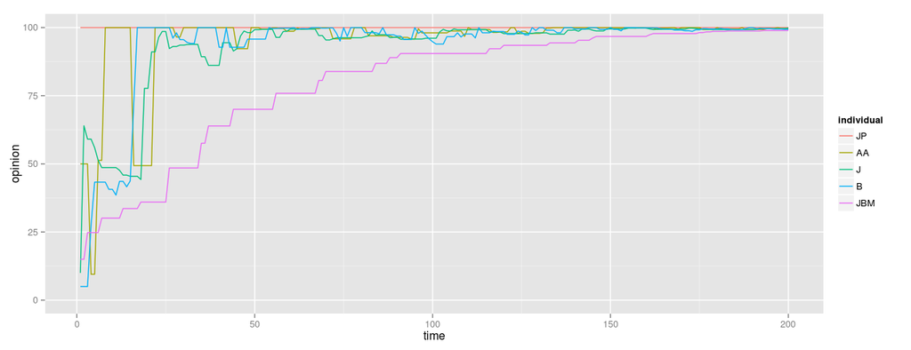

```r
T <- 200
X <- matrix(NA, nrow=nrow(alpha), ncol=T)
rownames(X) <- rownames(alpha)
X[,1] <- inits
update <- function(X, t){
  edge <- str_split(edgeNames(g), "~")[[sample.int(numEdges(g),1)]]
  i <- edge[1] ; j <- edge[2]
  xi <- X[i,t-1] ; xj <- X[j,t-1]
  X[i,t] <- (1-alpha[i,j])*xi + alpha[i,j]*xj
  X[j,t] <- (1-alpha[j,i])*xj + alpha[j,i]*xi
  others <- setdiff(rownames(X), edge)
  X[others,t] <- X[others,t-1]
  return(X)
}
for(t in 2:T){
  X <- update(X,t)
}
sims <- data.frame(time=1:T, t(X))
ggdata <- melt(sims, id.vars="time", variable.name="individual", value.name="opinion")
ggplot(ggdata, aes(x=time, y=opinion, color=individual)) +
   geom_line() +
  xlim(c(1,T)) + ylim(c(0,100))
```

## A two-stubborns example

Let’s modify the trusting parameters of `JBM` as well as his initial opinion value. We set all to $0$, so that `JBM` is now the subborn opposite to `JP`.

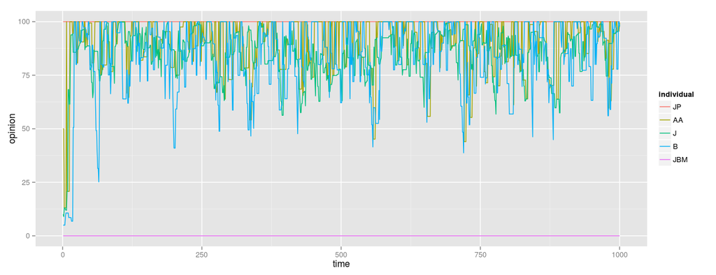

```r
inits["JBM"] <- 0
alpha["JBM","J"] <- 0
T <- 1000
X <- matrix(NA, nrow=nrow(alpha), ncol=T)
rownames(X) <- rownames(alpha)
X[,1] <- inits
update <- function(X, t){
  edge <- str_split(edgeNames(g), "~")[[sample.int(numEdges(g),1)]]
  i <- edge[1] ; j <- edge[2]
  xi <- X[i,t-1] ; xj <- X[j,t-1]
  X[i,t] <- (1-alpha[i,j])*xi + alpha[i,j]*xj
  X[j,t] <- (1-alpha[j,i])*xj + alpha[j,i]*xi
  others <- setdiff(rownames(X), edge)
  X[others,t] <- X[others,t-1]
  return(X)
}
for(t in 2:T){
  X <- update(X,t)
}
sims <- data.frame(time=1:T, t(X))
ggdata <- melt(sims, id.vars="time", variable.name="individual", value.name="opinion")
ggplot(ggdata, aes(x=time, y=opinion, color=individual)) +
   geom_line() +
  xlim(c(1,T)) + ylim(c(0,100))
```

```r
#knit_exit()
```

You have to embed the jQuery and SciAnimator libraries in the HTML header (between `<head>` and `</head>`), even though some browsers can tolerate it if you insert a style sheet after `<body>`.

```r
for(t in 1:20){
  gg <- ggplot(subset(ggdata, time<=t), aes(x=time, y=opinion, color=individual)) +
     geom_line() +
    xlim(c(1,T)) + ylim(c(0,100))
  print(gg)
  }
## geom_path: Each group consist of only one observation. Do you need to adjust the group aesthetic?
```

[output not shown]

```r
knit_exit()
```